# David Josephs

# About Me

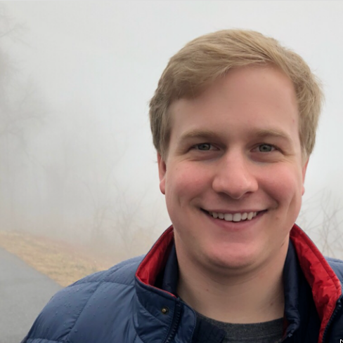

I am a:

- Aspiring data scientist
- Open source contributor (author of 1.5 [R packages](https://rdrr.io/github/josephsdavid/tswgewrapped/) and 1 [python package](https://pypi.org/project/n2d/))
- [Chess player](https://lichess.org/@/SchevyHeavy)
- Vim and Linux enthusiast
- [TA to a graduate level data science course](https://github.com/josephsdavid/teachR)

# My blog

## Data Science Blog:

Home Page

### Recent Articles:

Building a Reproducible Data Science Environment with Nix

Forecasting Air Pollution Part 1: Preprocessing

Forecasting Air Pollution Part 2: Univariate Exploratory Data Analysis

## Chess Blog

Work in progress

# Things I love

- R
- Python
- [Nix](https://nixos.org/nix/)
- Long walks
- Chess
- Writing
- Ensemble Models
- Time Series
- Dynamic Time Warping
- Keras
- American cheese
- Association rule mining
- My dog

# Things I am doing

- Getting a master’s in data science
- Working on my capstone project (Unsupervised and Supervised Learning for MS Diagnoses):
  - Build SVM and LSTM based classifiers using gait data to determine EDSS score computationally
  - Cluster gait data to build a new mobility metric for MS patients as well as highlight relationships between other MS phenotypes and gait
- Helping graduate students succeed and understand the entire data science workflow from data attainment to deployment (head TA for a survey of data science course)
- Going in depth with deep learning
  - Building fake images of food with a GAN (future blog post)
  - Working on image classification with CNNs
  - Time series analysis with LSTMs and WaveNet CNN architecture
  - (Hopefully) building a chess AI that uses reinforcement learning
- Maintaining and growing my first large python library

# Things I have done

- Worked for NASA
  - Acted as translator, astronomer, and lead scout for the [ultima thule mission](https://www.nasa.gov/feature/nasa-s-new-horizons-team-strikes-gold-in-argentina/)
  - [Conducted televised interviews in Argentina](https://twitter.com/UVaOccultChaser/status/885859356054622209)
- Performed [extensive time series analysis](https://github.com/josephsdavid/ChinesePM) of $PM_{2.5}$ content in Beijing, using models ranging from ARIMA and VAR to LSTMs, and ensembling methods
- Conducted [ARM using R](https://github.com/drake-smu/7331-lab-3) on census data, yielding unsurprising results
- Extensively done [classification on census data using python](https://github.com/drake-smu/7331-lab-2)
- Built a snowflake schema data store at [treehouse](https://www.dmagazine.com/sponsored/2017/06/treehouse-has-arrived-in-dallas/)
  - Developed a SKU system for all products, ranging from paint to refrigerators
- Managed data analytics for a local election at [Uptown Dallas, Inc](http://uptowndallas.net/)